### https://www.kaggle.com/competitions/shopee-product-matching/overview

# Shopee 요약

- Shopee의 주요 동남아시아 및 대만 전자상거래 플랫폼
- 문제는 2021년 Kaggle 대회 `Shopee Product Matching` 기반

# 🛍️ Shopee Product Matching 문제 요약 및 모델 구조 정리

## 🔍 문제 개요

- **목표**: 같은 상품인지(=동일 `label_group`) 여부를 **이미지+텍스트** 정보를 통해 자동 판별하는 멀티모달 상품 매칭 문제
- **배경**: Shopee 플랫폼에는 동일 상품이 다른 사진/제목으로 여러 번 등록됨 → 이를 자동으로 매칭해야 함
- **원래 대회 포맷**: 쿼리 상품에 대해 유사한 상품을 찾는 **retrieval 문제**
- **재구성 방식**: 쌍(pair) 단위의 **이진 분류 문제**로 변환하여 모델 학습
- **모델 역할**: 두 샘플(이미지 + 텍스트 쌍)을 입력받아, 두 제품이 동일한 상품(같은 label_group)인지 여부를 예측하는 이진 분류 기반의 pairwise matching 모델

## 🧠 모델 구조 및 특징

### 📥 입력

- 한 쌍의 상품:
  - **상품 제목 (`title`)** 2개
  - **상품 이미지 (`.jpg`)** 2개

※ 내부적으로 CLIPProcessor를 통해 다음처럼 전처리됨:

- 텍스트 → `input_ids`, `attention_mask`
- 이미지 → `pixel_values`

### ⚙️ 내부 처리

- **CLIP 모델 (HuggingFace 기반)** 사용  
  → 텍스트와 이미지 임베딩 각각 추출 (512-dim씩)
- 임베딩 결합 방식:
  1. 각 샘플의 이미지+텍스트 임베딩 → concat → 1024차원
  2. 두 샘플 벡터 → concat → 총 512 × 4 = 2048차원
- 분류기(classifier)를 통해 유사 여부 예측 (로짓 → 시그모이드 → 확률값)

### 📤 출력

- 확률값 (0~1): 두 상품이 같은 상품일 확률 → 임계값(예: 0.5) 이상이면 positive (같은 상품)으로 분류

## 🏗️ 학습 및 평가 설계

- **데이터 구성**
  - 이미지 + 텍스트 정보
  - `label_group` 기준으로 동일 상품 여부 확인
- **그룹 단위로 Train/Val/Test 분할**
  - 같은 그룹에 속한 제품들은 같은 split에 배정하여 정보 누출 방지
- **쌍 생성 로직**
  - Positive: 같은 그룹 상품 쌍
  - Negative: 다른 그룹 쌍 (Positive 대비 최대 2배)
- **Loss Function**: `BCEWithLogitsLoss`
- **평가**: Accuracy (※ F1 score도 함께 평가하는 걸 권장. 현재는 Acc만 출력.)

## 🧩 모델 구현 요약

| 항목 | 내용 |
| --- | --- |
| 기반 모델 | HuggingFace CLIP (`openai/clip-vit-base-patch32`) |
| 모델 형태 | Siamese 멀티모달 분류기 |
| 사전학습 | Full fine-tuning (freeze 없음) |
| 입력 형식 | 텍스트 토큰 + 이미지 픽셀값 쌍 |
| 출력 형식 | 두 상품의 동일 여부 확률 (0~1) |

## ✅ 비즈니스 적용 가능성 평가

### 👍 장점

- 이미지+텍스트 동시 활용 → 정확도 향상
- CLIP 기반 강력한 표현력
- 확률 출력 → threshold 조정 유연
- Siamese 구조 → 실시간 매칭 시스템에 적합

### ⚠️ 단점 및 한계

- 학습 데이터에 없는 상품군에는 일반화 어려움
- 추론 속도/비용 부담 (쌍 비교 구조)
- 이미지 품질/상품 제목 표현 차이에 민감

## 🏭 실제 서비스 적용 흐름

### 1. 임베딩 사전 계산

- 전체 상품에 대해 CLIP 임베딩 추출 (멀티모달 기반 임베딩 : 이미지+텍스트) → 저장 (DB, 파일 등)
- fine-tuning된 모델 사용 시, 임베딩도 재계산 필요

### 2. 후보군 필터링

- 텍스트 기반 검색 (BM25, TF-IDF 등)
- 이미지/텍스트 임베딩 기반 ANN(Approximate Nearest Neighbor) 검색 (FAISS 등)
  - 임베딩: 입력 이미지와 텍스트를 고차원 벡터 공간으로 변환한 표현
  - ANN 자체는 일반적으로 "학습"하지 않고, 인덱스를 구축하는 과정만 필요

### 3. 정밀 매칭

- 후보 쌍에 대해 Siamese 모델로 유사 확률 예측
- 또는 cosine similarity 등 간단 방식 병용 가능

### 4. 후처리 (활용)

- 중복 상품 통합 및 가격 비교 페이지 구성, ‘최저가 보장’ 프로모션 적용, 콘텐츠 기반 추천 시스템 등 활용
- 유사 제품 자동 식별은 중복 등록, 가격 비교, 추천 필터링 등에서 핵심

### 5. 운영 및 업데이트

- 신상품, 신상품군 등장 대비 정기적 임베딩 재계산 및 모델 재학습
- 성능 모니터링, GPU 최적화, 캐싱 등 고려
- (추후 확장 가능성: 실시간 대응 구조로 전환. 추론 시에도 한 상품의 임베딩만 저장해두고 다른 상품과 비교하는 구조로 만들 수 있어, retrieval 시스템으로 확장.)

## 💡 소규모 쇼핑몰 적용성

- GPU 1~2대 또는 저사양 클라우드 인스턴스로 충분히 운영 가능
- 상품 수 천 개까지도 문제 없음 (임베딩 저장 + ANN 탐색 구조 활용 시)
- 운영 간단 (임베딩 생성/저장, 추론 API, 주기적 재계산)

## 🔚 최종 결론

- **모델 의미**: 상품 중복 제거, 가격 비교, 유사 상품 추천 등에 실질적으로 적용 가능
- **모델 구조 적합성**: 문제 정의에 딱 맞는 모델 구조 (CLIP + Siamese)
- **실무 가능성**: 성능·운영·적용성 모두 현실적으로 타당  
  → 데이터 품질 관리 및 threshold 조정 등으로 충분히 프로덕션 사용 가능

## 🔧 CLIP 기반 Pairwise 이진 분류 + ANN 활용 구조

```
📦 기존 상품 DB
    ├── 이미지1 + 텍스트1 ─▶ CLIP ─┐
    ├── 이미지2 + 텍스트2 ─▶ CLIP ─┤
    └── ...                       ─▶ 임베딩 벡터 저장
                                     (Vector DB, 예: FAISS)

🆕 새 상품 (이미지 + 텍스트)
    └─▶ CLIP ──▶ 새 상품 임베딩 생성

              ▼
🔍 ANN 검색 (FAISS 등)
    └─▶ 기존 상품 임베딩 중 Top-K 유사 후보 추출

              ▼
🧩 Pair 구성
    ├── (새 상품, 후보1)
    ├── (새 상품, 후보2)
    └── ...

              ▼
🧠 Pairwise Matching Model (이진 분류기)
    └─▶ 각 쌍 입력 → 같은 상품일 확률 (0~1) 출력

              ▼
✅ 최종 결과
    ├── 확률이 가장 높은 후보 선택
    └── 또는 Top-N 후보 반환
```

### 📌 구성 요소 설명

| 구성 요소 | 설명 |
| --- | --- |
| **CLIP** | 이미지+텍스트 입력 → 멀티모달 임베딩 생성 |
| **Vector DB (FAISS)** | 기존 상품 임베딩 저장 및 ANN 검색 |
| **Pairwise Classifier** | 두 임베딩을 비교해 같은 상품 여부 (0~1) 예측 |
| **입력 쌍 구성** | 새 상품과 Top-K 후보 조합 후 분류기 입력 |

### 🧠 모델 방식 요약

- 🔸 학습: CLIP + 이진 분류기 (쌍 입력 → 0/1 예측)
- 🔸 추론: ANN으로 후보 압축 → 분류기로 정밀 판별

## 모델 사용 구조

1. 허깅페이스 모델 사용 — 맞습니다. from transformers import CLIPProcessor, CLIPModel 로 불러오고, CLIPModel.from_pretrained(...) 로 모델 로딩하는 부분이 명확히 허깅페이스 Transformers API입니다.
2. 사전학습 웨이트 사용 — 맞습니다. "openai/clip-vit-base-patch32"는 공개된 CLIP 사전학습 모델 이름이며, from_pretrained() 호출 시 자동으로 허깅페이스 허브에서 사전학습된 가중치를 가져와 로드합니다.

만약 사전학습된 CLIP 모델을 동결(freeze) 하고 새 층만 학습시키면 더 엄밀히 “전이학습” 중 일부만 미세조정하는 상황인데, 지금 코드는 동결 코드를 안 썼으니 전체를 학습하는 완전한 전이학습(fine-tuning) 형태입니다. (requires_grad = False 같은 freeze 코드가 없으므로, 전체 파라미터가 학습 대상이 되는 full fine-tuning이 맞습니다.)

허깅페이스(Transformers) 라이브러리에서 제공하는 CLIP 모델을 사용하고 있습니다. 사전학습된 CLIP을 기반으로 Siamese 구조를 덧붙여서 쌍(pair) 분류 문제에 맞게 fine-tuning 하는 구조입니다.

### 훈련 시 개선 가능한 요소들 (파인튜닝보다 복잡한 난이도)

#### 정확도 기반 평가

실제 대회 기준은 F1-score이므로, accuracy 외에 F1도 로깅하도록 개선 필요. 특히 불균형 상황에서 accuracy는 무의미할 수 있음.

#### Negative Pair Sampling

지금은 무작위 negative지만, hard negative mining이나 phash 유사도 기반으로 더 어려운 negative를 만들면 모델 학습 성능이 더 향상될 수 있음.

#### Embedding 저장 후 검색 기반으로 전환

현재는 쌍별 입력이지만, 추론 시간 고려 시 title/image embedding → 저장 → 유사도 매칭 구조로 바꾸면 retrieval 시스템 구현 가능.

#### 모델 구조 확장성

현재는 단순 concatenation → linear이지만, concat 후 Cosine Similarity + Triplet Loss 또는 Contrastive Loss로도 학습 가능 (retrieval 친화적).

# 프로젝트 폴더 구조

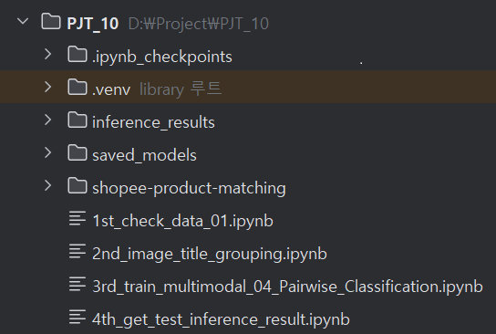

[figure not shown]

[figure not shown]

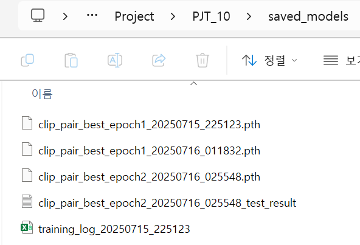

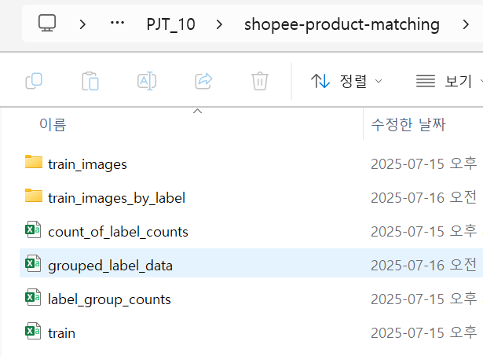

[figure not shown]

# 환경 설정

### 아래 설치

- jupyter / scikit-learn / pandas / matplotlib / tensorflow==2.15.0
- pip install opencv-python matplotlib pandas seaborn
- pip3 install torch torchvision torchaudio --index-url https://download.pytorch.org/whl/cu128

그외 코드 오류 발생 시 다 설치

# 파이썬 인터프리터, 설치된 패키지 (참고용)

[figure not shown]

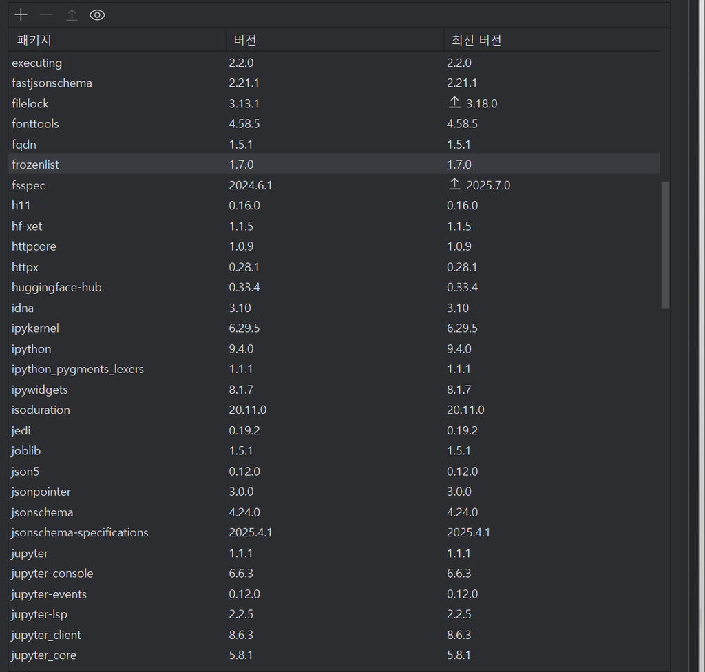

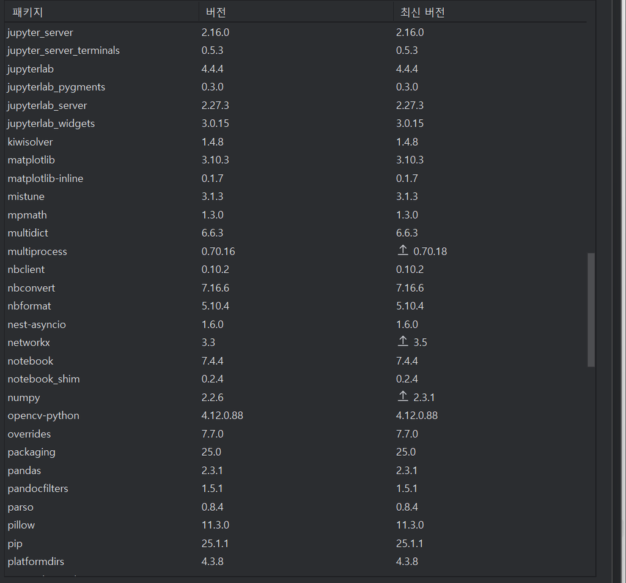

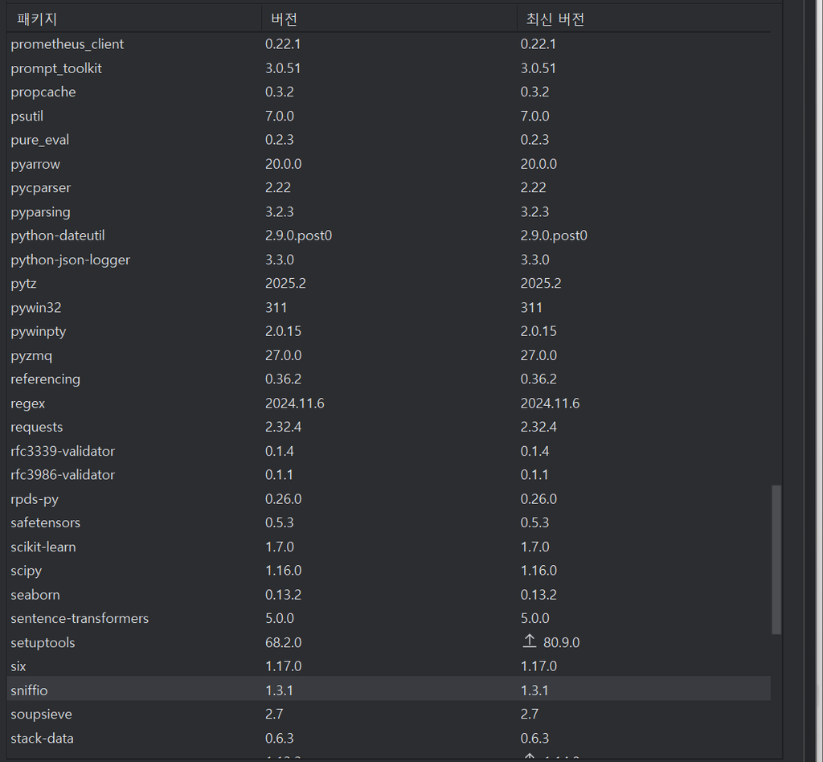

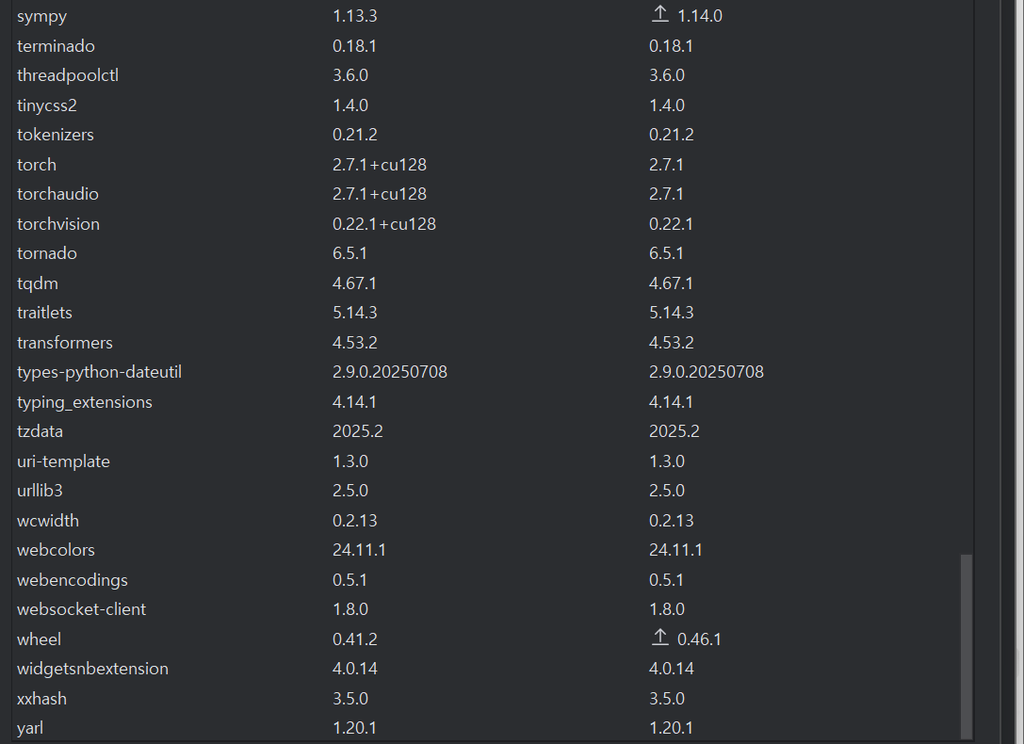

# GPU 사용률 (참고용)

- 실행 파일: 3rd_train_multimodal_04_Pairwise_Classification.ipynb
- BATCH_SIZE = 32, EPOCHS = 10, patience = 5
- 한 에폭 당 1시간 20분 정도 소요

[figure not shown]

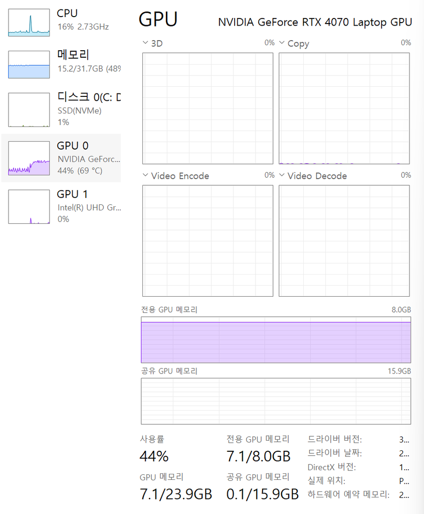

PPT

- https://www.canva.com/templates/EAGWvS9I718/
- https://www.canva.com/templates/EAF-h8HEjjI/
- https://www.canva.com/templates/EAFzFFNpQEU/
- https://www.canva.com/templates/EAGpLkCWD6c/
- https://www.miricanvas.com/templates/presentation/1bqma-%EB%B3%B4%EB%9D%BC%EC%83%89%EC%9D%98-%EC%8B%AC%ED%94%8C%ED%95%9C-%EB%A9%A4%EB%B2%84%EC%8B%AD%EC%B9%B4%EB%93%9C-%ED%94%84%EB%A1%9C%EB%AA%A8%EC%85%98-%EA%B8%B0%ED%9A%8D%EC%84%9C-%ED%94%84%EB%A0%88%EC%A0%A0%ED%85%8C%EC%9D%B4%EC%85%98

웹디자인

- https://www.figma.com/community/file/1321464360558173342
- https://www.figma.com/community/file/1184498378829556800
- https://www.figma.com/community/file/1332692166039368405
- https://www.figma.com/community/file/1061606187032379123
- https://www.figma.com/community/file/1335661394292979934
- https://htmlcodex.com/bootstrap-shop-template/
- https://htmlcodex.com/online-shop-website-template/